# Homework 5

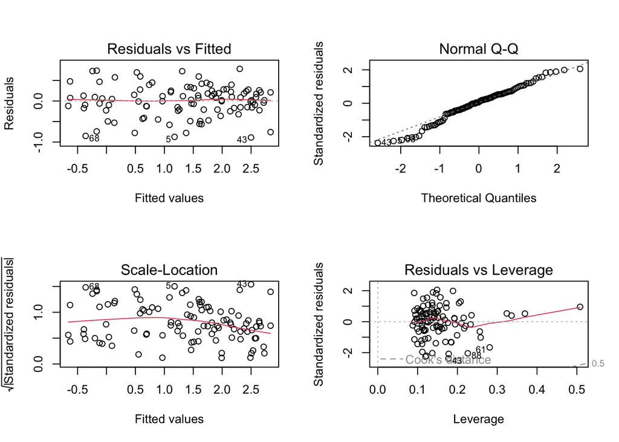

```r
#create log transformation of full model
full_log <- lm(log(totmass) ~ species + feedlevel + sla + chlorophyll + amass + num_lvs + num_phylls, data = plant_subset)
#check assumptions
par(mfrow = c(2,2))
plot(full_log)
```

**Figure 5.** Assumption checks for the full log model. Four plots used to determine the normality of full mode. Residual vs Fitted show residuals on y-axis and fitted values on x-axis. Normal Q-Q plot had standardized residuals on the y-axis and theoretical quantities on the x-axis. Scale-location show the square root of standardized residuals on the y-axis and fitted values on the x-axis. Residuals vs leverage show standardized residuals on the y-axis, leverage on x-axis, and cooke’s distance represented by dotted lines.

```r
#check assumptions for full model log transformation
check_normality(full_log)
```

```
## OK: residuals appear as normally distributed (p = 0.107).
```

```r
check_heteroskedasticity(full_log)
```

```
## OK: Error variance appears to be homoscedastic (p = 0.071).
```

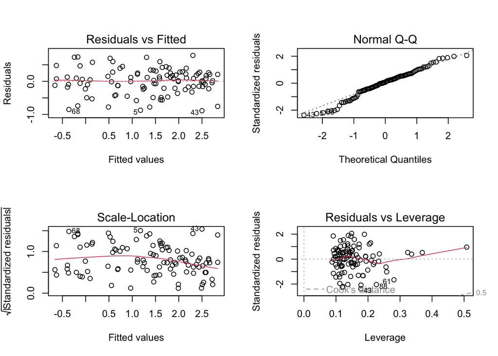

```r
#create log transformations of null and full model
null_log <- lm(log(totmass) ~ 1, data = plant_subset)
full_log <- lm(log(totmass) ~ species + feedlevel + sla + chlorophyll + amass + num_lvs + num_phylls, data = plant_subset)
#check assumptions
par(mfrow = c(2,2))
plot(full_log)
```

```r
check_normality(full_log)
```

```
## OK: residuals appear as normally distributed (p = 0.107).
```

```r
check_heteroscedasticity(full_log)
```

```
## OK: Error variance appears to be homoscedastic (p = 0.071).
```

```r
#evaluate multicollinearity
vif(full_log)
```

```
##                  GVIF Df GVIF^(1/(2*Df))
## species     42.351675  9        1.231351
## feedlevel    1.621993  1        1.273575
## sla          1.999989  1        1.414210
## chlorophyll  1.949828  1        1.396362
## amass        2.872084  1        1.694722
## num_lvs      2.813855  1        1.677455
## num_phylls   2.995510  1        1.730754
```

```r
#create other models
model2_log <- lm(log(totmass) ~ species, data = plant_subset)
model3_log <- lm(log(totmass) ~ species + chlorophyll, data = plant_subset)
model4_log <- lm(log(totmass) ~ feedlevel + species, data = plant_subset)
```

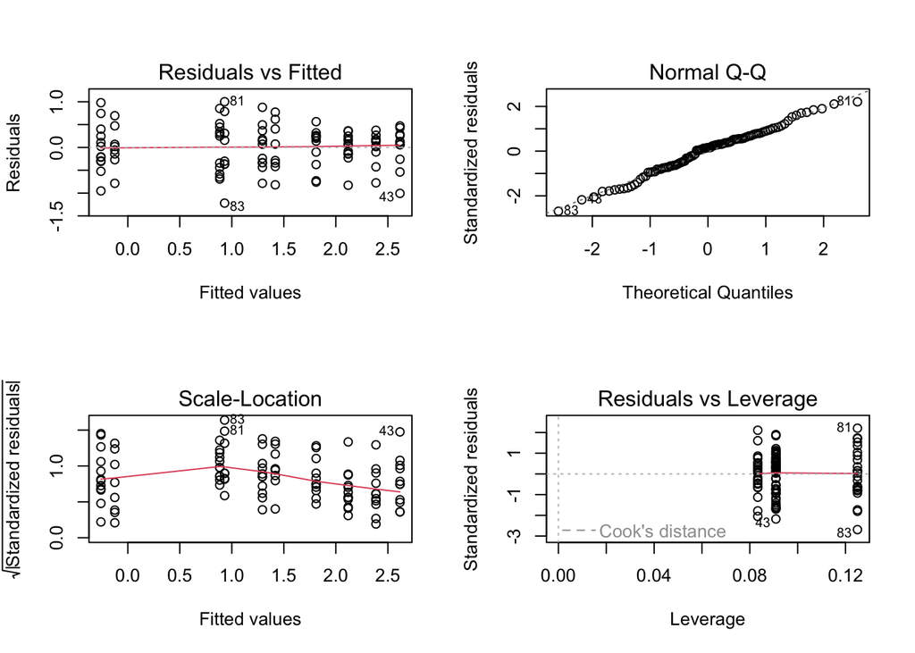

```r
#check assumptions for model 2
par(mfrow = c(2,2))
plot(model2_log)
```

**Figure 6.** Assumption checks for model 2. Four plots used to determine the normality of full mode. Residual vs Fitted show residuals on y-axis and fitted values on x-axis. Normal Q-Q plot had standardized residuals on the y-axis and theoretical quantities on the x-axis. Scale-location show the square root of standardized residuals on the y-axis and fitted values on the x-axis. Residuals vs leverage show standardized residuals on the y-axis, leverage on x-axis, and cooke’s distance represented by dotted lines.

```r
#check assumptions for model 2
check_normality(model2_log)
```

```
## OK: residuals appear as normally distributed (p = 0.374).
```

```r
check_heteroskedasticity(model2_log)
```

```
## OK: Error variance appears to be homoscedastic (p = 0.100).
```

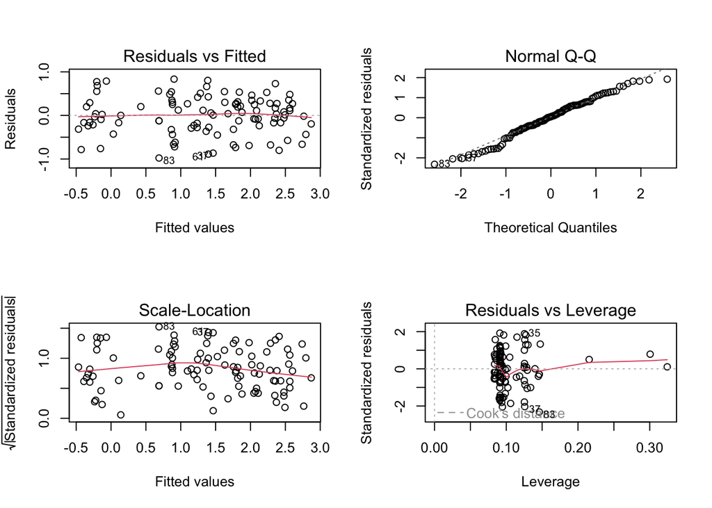

```r
#check assumptions for model 3
par(mfrow = c(2,2))
plot(model3_log)
```

**Figure 7.** Assumption checks for model 3. Four plots used to determine the normality of full mode. Residual vs Fitted show residuals on y-axis and fitted values on x-axis. Normal Q-Q plot had standardized residuals on the y-axis and theoretical quantities on the x-axis. Scale-location show the square root of standardized residuals on the y-axis and fitted values on the x-axis. Residuals vs leverage show standardized residuals on the y-axis, leverage on x-axis, and cooke’s distance represented by dotted lines.

```r
#check assumptions for model 3
check_normality(model3_log)
```

```
## OK: residuals appear as normally distributed (p = 0.134).
```

```r
check_heteroskedasticity(model3_log)
```

```
## OK: Error variance appears to be homoscedastic (p = 0.327).
```

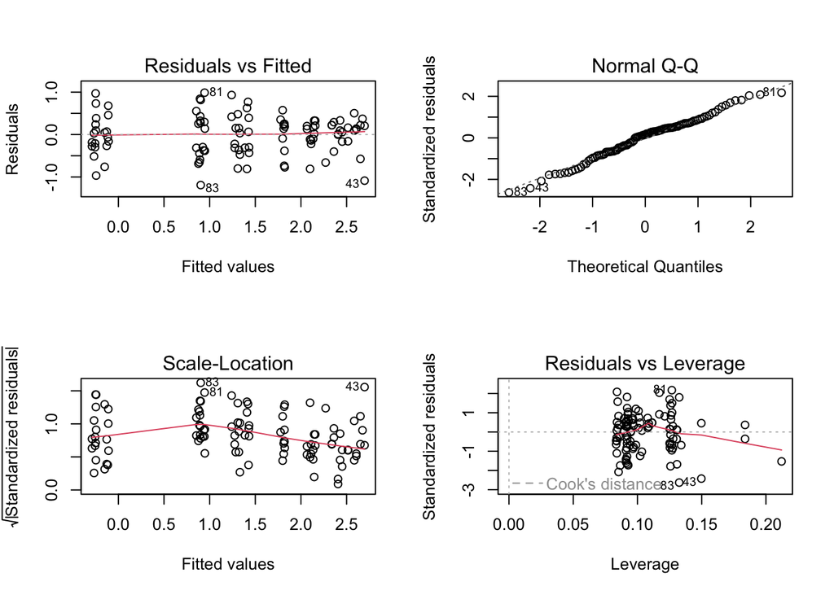

```r
#check assumptions for model 4
par(mfrow = c(2,2))
plot(model4_log)
```

**Figure 8.** Assumption checks for model 4. Four plots used to determine the normality of full mode. Residual vs Fitted show residuals on y-axis and fitted values on x-axis. Normal Q-Q plot had standardized residuals on the y-axis and theoretical quantities on the x-axis. Scale-location show the square root of standardized residuals on the y-axis and fitted values on the x-axis. Residuals vs leverage show standardized residuals on the y-axis, leverage on x-axis, and cooke’s distance represented by dotted lines.

```r
#check assumptions for model 4
check_normality(model4_log)
```

```
## OK: residuals appear as normally distributed (p = 0.339).
```

```r
check_heteroskedasticity(model4_log)
```

```
## OK: Error variance appears to be homoscedastic (p = 0.110).
```

```r
#Compare models using Akaline's Information criterion values
AICc(full_log)
```

```
## [1] 133.9424
```

```r
AICc(model2_log)
```

```
## [1] 157.5751
```

```r
AICc(null_log)
```

```
## [1] 306.0028
```

```r
AICc(model3_log)
```

```
## [1] 146.0276
```

```r
AICc(model4_log)
```

```
## [1] 159.6218
```